# Data Analysis Replication Assignment

Jyhreh Johnson

3/8/2022

## Introduction

```r
#allow user to download all packages used for project
require(tidyverse)
require(ggplot2)
require(ggfortify)
require(MASS)
require(caret)
require(lars)
require(stats)
require(FactoMineR)
require(factoextra)
require(geomorph)
```

## Visualization of Data

This section of the project, allows you to see the first three lines of each data set. I acquired the data used in Martinez 2017 from Dryad, an open data repository where authors can post their collected data. The coordinates of the landmarks taken from each specimen where visualized originally in a .txt format. For ease of coding, I converted the .txt files to .csv. The data sets also include body and oral jaw centroid size and the maxillary kinematic transmission.

```r
#Figure data
bs_f <- "https://raw.githubusercontent.com/jyhrehjohnson/data_analysis_replication/main/data/body%20shape%20coordinates.csv"
d1 <- read.csv(bs_f, header = TRUE, stringsAsFactors = FALSE)
```

```r
head(d1,3) #print the first 3 lines of data for visualization
```

```
##                  species         x1          y1         x2          y2
## 1   Paretroplus_lamenabe -0.1505010 -0.02837617 0.07632234 -0.06296149
## 2    Paretroplus_tsimoly -0.1494062 -0.02921048 0.07118195 -0.05784125
## 3 Paretroplus_nourissati -0.1518861 -0.02913070 0.06693868 -0.05667939
##           x3         y3         x4        y4        x5        y5         x6
## 1 -0.1601932 0.04121896 0.03470775 0.1139943 0.1039550 0.1062656 0.04702003
## 2 -0.1616744 0.03673270 0.02870553 0.1117984 0.1042815 0.1077207 0.04106447
## 3 -0.1597977 0.03681009 0.03569000 0.1056886 0.1057775 0.1019254 0.04584630
##           y6         x7         y7         x8         y8        x9         y9
## 1 0.08022339 0.06078658 0.05587950 0.08189101 0.02109496 0.1235903 0.02416901
## 2 0.07595027 0.05557469 0.05222829 0.07907820 0.01955031 0.1226098 0.01781948
## 3 0.07223749 0.06043979 0.04710786 0.08067136 0.01558552 0.1257772 0.01852821
##         x10        y10       x11        y11        x12         y12        x13
## 1 0.1479348 0.02724776 0.1559304 0.07249514 -0.1714988 -0.02570297 -0.1589964
## 2 0.1516509 0.02200092 0.1669604 0.06483725 -0.1747850 -0.02977550 -0.1614154
```

[output cut: 61 more lines]

```r
#Figure data
fbs_f <- "https://raw.githubusercontent.com/jyhrehjohnson/data_analysis_replication/main/data/fourbar%20shape%20coordinates.csv"
d2 <- read.csv(fbs_f, header = TRUE, stringsAsFactors = FALSE)
```

```r
head(d2,3) #print the first 3 lines of data for visualization
```

```
##                  species         x1          y1         x2          y2
## 1   Paretroplus_lamenabe -0.6174378 -0.09967832 -0.1439847 -0.03335393
## 2    Paretroplus_tsimoly -0.5952670 -0.08443220 -0.1581017 -0.03436393
## 3 Paretroplus_nourissati -0.6045838 -0.10132320 -0.1541514 -0.04202661
##          x3        y3        x4         y4
## 1 0.1652786 0.3823117 0.5961439 -0.2492795
## 2 0.1315709 0.3845709 0.6217979 -0.2657748
## 3 0.1671701 0.4018568 0.5915651 -0.2585069
```

```r
#Figure data
species_f <-"https://raw.githubusercontent.com/jyhrehjohnson/data_analysis_replication/main/data/species%20info.csv"
d3 <- read.csv(species_f, header = TRUE, stringsAsFactors = FALSE)
```

```r
head(d3,3) #print the first 3 lines of data for visualization
```

```
##                  species  subfamily body_centroid_size jaw_centroid_size
## 1   Paretroplus_lamenabe Etroplinae           44.91203          2.318948
## 2    Paretroplus_tsimoly Etroplinae           32.32512          1.539906
## 3 Paretroplus_nourissati Etroplinae           26.36893          1.276342
##         MKT
## 1 0.8940651
## 2 0.8062424
## 3 0.8215598
```

## Statistical Replications/Reanalysis

## Figure 4 Replication | PCA of Body Phylomorphospace

**Data Preparation**

In this section of code, I prepped the dataset in order to make the actual principle component analysis easier. Here I created a new variable bs_data which is the d1 data set. Next, I modified the original d1 dataset to separate the species column into genus name and species name. (This allowed me to later color the data points by genus.) I added the new column ‘genus’ to the bs_data dataset, then I moved the genus name after the species name in the data set.

```r
#Prep the data
bs_data <- d1
d1_mod <- str_split_fixed(d1$species, "_", 2) #Split the original species column into two (Genus name & Species name)
d1_mod <- as.data.frame(d1_mod, row.names = NULL, optional = FALSE) #Make the modified data set a data frame
bs_data_mod <- d1 %>% mutate(genus = d1_mod$V1) #Add the column genus
bs_data_mod <- bs_data_mod %>% relocate(genus, .after = species) #Move the new genus column after the species column
```

**PCA Analysis**

After prepping the data, I calculated the principle components. I started by scaling the data removing the first column of data, leaving only numeric values. Then I got the eigen values from the dataset. Next I scaled the eigen values and calculated their variance. Lastly, I used the prcomp function to calculate the pca.

```r
#Calculate the Principal Components
bs_data_scaled <- scale(bs_data[, -1], #Use the bs_data removing the first column, leaving only numeric values in the dataset.
                     center = TRUE,
                     scale = TRUE)
head(bs_data_scaled,3)
```

```
##              x1         y1         x2         y2         x3        y3
## [1,] -0.9247697 0.39215697 -0.7399731 -0.5914123 -0.8917127 -0.293717
## [2,] -0.8476032 0.07008335 -1.4965048  0.3003893 -1.0082365 -1.114339
## [3,] -1.0224057 0.10088056 -2.1210048  0.5027519 -0.8606045 -1.100182
##              x4          y4         x5         y5         x6         y6
## [1,] -0.5330425  0.42755862 -0.9874639  0.5868575 -0.3456896  0.8601757
## [2,] -1.6342817  0.08084768 -0.9280350  0.8753912 -1.2302398 -0.2404674
## [3,] -0.3528284 -0.88385316 -0.6557731 -0.2738065 -0.5200188 -1.1967799
##              x7         y7         x8         y8          x9         y9
## [1,] -0.2642154  0.4539746 -0.9018554 1.29939186 -0.41841129 -0.2940975
## [2,] -1.0613038 -0.5414621 -1.4370333 0.94532178 -0.59061942 -1.5847903
## [3,] -0.3172528 -1.9374580 -1.1339118 0.03649499 -0.03429661 -1.4407237
##             x10        y10        x11        y11          x12         y12
## [1,] -1.0415658 -0.5032347 -0.5252357  0.3700724  0.401125872  0.90446360
## [2,] -0.5933320 -1.5326330  1.1327206 -1.4267645  0.006830504 -0.04665191
```

[output cut: 61 more lines]

```r
e1 <- eigen(cov(bs_data[, -1]))
head(e1,3) #Print the first 3 lines of data for visualization
```

```
## $values
##   [1]  2.355307e-03  9.738065e-04  2.383607e-04  1.203477e-04  9.264794e-05
##   [6]  5.710726e-05  3.994398e-05  2.590352e-05  1.965731e-05  1.661906e-05
##  [11]  1.234311e-05  9.267116e-06  6.671708e-06  6.068836e-06  4.958278e-06
##  [16]  3.840522e-06  3.094689e-06  2.352968e-06  2.141651e-06  1.720171e-06
##  [21]  1.498767e-06  9.809612e-07  6.947766e-07  3.017687e-07  2.224464e-07
##  [26]  5.794117e-19  1.238268e-19  4.933805e-20  3.264925e-20  2.957478e-20
##  [31]  2.442539e-20  2.199515e-20  1.797446e-20  1.524499e-20  1.386179e-20
##  [36]  1.208148e-20  1.130168e-20  1.076332e-20  8.952120e-21  8.615869e-21
##  [41]  7.758763e-21  7.060012e-21  6.726780e-21  5.585180e-21  5.576094e-21
##  [46]  4.456742e-21  3.743016e-21  3.418514e-21  3.012624e-21  2.762093e-21
##  [51]  2.530728e-21  1.863643e-21  1.859569e-21  1.813139e-21  1.696663e-21
##  [56]  1.601584e-21  1.157388e-21  9.967886e-22  9.645887e-22  7.393154e-22
##  [61]  5.156968e-22  4.905138e-22  4.503809e-22  4.231398e-22  2.607133e-22
##  [66]  2.597636e-22  2.432304e-22  1.821295e-22  1.707375e-22  1.221131e-22
```

[output cut: 2820 more lines]

```r
e1.scaled <- eigen(cov(bs_data_scaled))
head(e1.scaled,3) #Print the first 3 lines of data for visualization
```

```
## $values
##   [1]  6.374903e+01  2.002991e+01  8.895448e+00  8.246861e+00  4.374563e+00
##   [6]  2.727248e+00  1.936338e+00  1.351519e+00  9.869712e-01  8.340230e-01
##  [11]  6.674991e-01  4.623475e-01  3.642403e-01  3.216441e-01  2.100279e-01
##  [16]  1.996135e-01  1.720967e-01  1.290564e-01  1.127232e-01  8.615013e-02
##  [21]  5.094905e-02  4.092686e-02  2.531322e-02  1.584239e-02  9.659932e-03
##  [26]  7.419392e-15  4.570287e-15  4.175090e-15  1.659552e-15  1.181309e-15
##  [31]  8.301692e-16  7.306641e-16  7.218577e-16  5.559597e-16  5.354537e-16
##  [36]  5.351614e-16  5.108136e-16  4.707552e-16  3.881558e-16  3.711637e-16
##  [41]  2.240651e-16  1.794576e-16  1.712610e-16  1.699212e-16  1.632591e-16
##  [46]  1.554829e-16  1.447849e-16  9.392348e-17  6.316207e-17  5.503976e-17
##  [51]  5.399206e-17  5.181309e-17  4.002251e-17  3.875652e-17  3.845514e-17
##  [56]  3.465163e-17  3.453959e-17  2.451607e-17  2.417840e-17  2.409237e-17
##  [61]  2.127077e-17  1.884372e-17  7.583894e-18  3.167559e-18  2.552790e-18
##  [66]  2.025708e-18 -1.242212e-18 -2.167877e-18 -6.810951e-18 -8.613432e-18
```

[output cut: 2820 more lines]

```r
e1.scaled$values #Calculate the variances
```

```
##   [1]  6.374903e+01  2.002991e+01  8.895448e+00  8.246861e+00  4.374563e+00
##   [6]  2.727248e+00  1.936338e+00  1.351519e+00  9.869712e-01  8.340230e-01
##  [11]  6.674991e-01  4.623475e-01  3.642403e-01  3.216441e-01  2.100279e-01
##  [16]  1.996135e-01  1.720967e-01  1.290564e-01  1.127232e-01  8.615013e-02
##  [21]  5.094905e-02  4.092686e-02  2.531322e-02  1.584239e-02  9.659932e-03
##  [26]  7.419392e-15  4.570287e-15  4.175090e-15  1.659552e-15  1.181309e-15
##  [31]  8.301692e-16  7.306641e-16  7.218577e-16  5.559597e-16  5.354537e-16
##  [36]  5.351614e-16  5.108136e-16  4.707552e-16  3.881558e-16  3.711637e-16
##  [41]  2.240651e-16  1.794576e-16  1.712610e-16  1.699212e-16  1.632591e-16
##  [46]  1.554829e-16  1.447849e-16  9.392348e-17  6.316207e-17  5.503976e-17
##  [51]  5.399206e-17  5.181309e-17  4.002251e-17  3.875652e-17  3.845514e-17
##  [56]  3.465163e-17  3.453959e-17  2.451607e-17  2.417840e-17  2.409237e-17
##  [61]  2.127077e-17  1.884372e-17  7.583894e-18  3.167559e-18  2.552790e-18
##  [66]  2.025708e-18 -1.242212e-18 -2.167877e-18 -6.810951e-18 -8.613432e-18
##  [71] -9.421940e-18 -1.719379e-17 -1.820296e-17 -2.773891e-17 -2.970209e-17
##  [76] -3.743312e-17 -4.305908e-17 -5.043331e-17 -5.512597e-17 -6.212278e-17
##  [81] -6.458412e-17 -6.466267e-17 -7.520014e-17 -8.020141e-17 -8.394144e-17
##  [86] -8.794657e-17 -9.217397e-17 -9.246392e-17 -9.694847e-17 -1.060606e-16
##  [91] -1.174569e-16 -1.285405e-16 -1.435180e-16 -1.525633e-16 -1.548871e-16
##  [96] -1.558682e-16 -1.684367e-16 -1.802096e-16 -1.897681e-16 -1.953165e-16
## [101] -2.087808e-16 -2.106499e-16 -3.282280e-16 -4.106756e-16 -4.346788e-16
## [106] -5.490857e-16 -5.671068e-16 -6.562287e-16 -7.597054e-16 -7.813030e-16
## [111] -7.889853e-16 -7.922983e-16 -9.042705e-16 -1.159344e-15 -1.972655e-15
## [116] -1.993486e-15
```

```r
e1.scaled$values/6 #Proportion of variances
```

```
##   [1]  1.062484e+01  3.338319e+00  1.482575e+00  1.374477e+00  7.290938e-01
##   [6]  4.545413e-01  3.227229e-01  2.252531e-01  1.644952e-01  1.390038e-01
##  [11]  1.112498e-01  7.705792e-02  6.070671e-02  5.360735e-02  3.500465e-02
##  [16]  3.326892e-02  2.868278e-02  2.150939e-02  1.878721e-02  1.435836e-02
##  [21]  8.491508e-03  6.821144e-03  4.218870e-03  2.640398e-03  1.609989e-03
##  [26]  1.236565e-15  7.617146e-16  6.958484e-16  2.765920e-16  1.968848e-16
##  [31]  1.383615e-16  1.217773e-16  1.203096e-16  9.265995e-17  8.924228e-17
##  [36]  8.919357e-17  8.513559e-17  7.845920e-17  6.469263e-17  6.186062e-17
##  [41]  3.734418e-17  2.990960e-17  2.854350e-17  2.832020e-17  2.720984e-17
##  [46]  2.591381e-17  2.413082e-17  1.565391e-17  1.052701e-17  9.173293e-18
##  [51]  8.998676e-18  8.635515e-18  6.670418e-18  6.459420e-18  6.409190e-18
##  [56]  5.775272e-18  5.756598e-18  4.086012e-18  4.029734e-18  4.015395e-18
##  [61]  3.545129e-18  3.140620e-18  1.263982e-18  5.279265e-19  4.254649e-19
##  [66]  3.376180e-19 -2.070354e-19 -3.613129e-19 -1.135159e-18 -1.435572e-18
##  [71] -1.570323e-18 -2.865632e-18 -3.033826e-18 -4.623151e-18 -4.950348e-18
##  [76] -6.238854e-18 -7.176513e-18 -8.405552e-18 -9.187661e-18 -1.035380e-17
##  [81] -1.076402e-17 -1.077711e-17 -1.253336e-17 -1.336690e-17 -1.399024e-17
##  [86] -1.465776e-17 -1.536233e-17 -1.541065e-17 -1.615808e-17 -1.767677e-17
##  [91] -1.957615e-17 -2.142342e-17 -2.391967e-17 -2.542722e-17 -2.581452e-17
##  [96] -2.597803e-17 -2.807279e-17 -3.003493e-17 -3.162801e-17 -3.255274e-17
## [101] -3.479679e-17 -3.510832e-17 -5.470467e-17 -6.844594e-17 -7.244647e-17
## [106] -9.151428e-17 -9.451780e-17 -1.093714e-16 -1.266176e-16 -1.302172e-16
## [111] -1.314976e-16 -1.320497e-16 -1.507117e-16 -1.932240e-16 -3.287759e-16
## [116] -3.322477e-16
```

```r
cumsum(e1.scaled$values/6) #Cumulative proportion
```

```
##   [1] 10.62484 13.96316 15.44573 16.82021 17.54930 18.00384 18.32657 18.55182
##   [9] 18.71631 18.85532 18.96657 19.04363 19.10433 19.15794 19.19294 19.22621
##  [17] 19.25490 19.27641 19.29519 19.30955 19.31804 19.32486 19.32908 19.33172
##  [25] 19.33333 19.33333 19.33333 19.33333 19.33333 19.33333 19.33333 19.33333
##  [33] 19.33333 19.33333 19.33333 19.33333 19.33333 19.33333 19.33333 19.33333
##  [41] 19.33333 19.33333 19.33333 19.33333 19.33333 19.33333 19.33333 19.33333
##  [49] 19.33333 19.33333 19.33333 19.33333 19.33333 19.33333 19.33333 19.33333
##  [57] 19.33333 19.33333 19.33333 19.33333 19.33333 19.33333 19.33333 19.33333
##  [65] 19.33333 19.33333 19.33333 19.33333 19.33333 19.33333 19.33333 19.33333
##  [73] 19.33333 19.33333 19.33333 19.33333 19.33333 19.33333 19.33333 19.33333
##  [81] 19.33333 19.33333 19.33333 19.33333 19.33333 19.33333 19.33333 19.33333
##  [89] 19.33333 19.33333 19.33333 19.33333 19.33333 19.33333 19.33333 19.33333
##  [97] 19.33333 19.33333 19.33333 19.33333 19.33333 19.33333 19.33333 19.33333
## [105] 19.33333 19.33333 19.33333 19.33333 19.33333 19.33333 19.33333 19.33333
## [113] 19.33333 19.33333 19.33333 19.33333
```

```r
bs_data_pc <- as.matrix(bs_data_scaled) %*% e1.scaled$vectors
head(bs_data_pc,3) #Print the first 3 lines of data for visualization
```

```
##           [,1]     [,2]     [,3]       [,4]      [,5]         [,6]       [,7]
## [1,] -4.880184 3.307925 1.735845 -1.1722920 -1.818867 -0.001731636  0.3710625
## [2,]  1.719389 2.504370 5.099499 -0.1007626 -3.476992  1.552660786 -0.9737634
## [3,]  5.046621 3.188075 5.163647 -0.3473188 -0.827191  1.311254114  0.2751632
##           [,8]       [,9]      [,10]       [,11]      [,12]      [,13]
## [1,] 0.1063059 -1.7250226 -0.5250213  0.08942816  0.1450063 -0.5146062
## [2,] 1.0170061  0.7607903 -0.2548548 -0.66508125 -0.9719180  0.4550779
## [3,] 0.3452762  1.7167966  0.3355985 -0.87695099  0.5283942  0.9170525
##            [,14]       [,15]      [,16]     [,17]      [,18]      [,19]
## [1,]  0.03501492  0.02788176 -0.4567467 0.3426945  0.5004642 -0.3820769
## [2,] -0.33756017 -0.21308686 -0.5286560 0.3373622 -0.3671011  0.3372412
## [3,] -0.21144497 -0.28952873  0.7091121 0.1176932  0.6480922 -0.1415022
##           [,20]      [,21]       [,22]      [,23]       [,24]       [,25]
## [1,]  0.1649193 -0.1173463  0.29257814  0.4350209 -0.08131429  0.14262070
## [2,]  0.2721846 -0.3142753  0.23021172 -0.1165828  0.19807827 -0.03420681
```

[output cut: 77 more lines]

```r
bs_pca <- prcomp(bs_data[, -1], #Use the bs_data removing the first column, leaving only numeric values in the dataset.
             center = TRUE,
             scale. = TRUE)
head(bs_pca$x,3) #Print the first 3 lines of data for visualization
```

```
##            PC1       PC2      PC3        PC4      PC5          PC6        PC7
## [1,] -4.880184 -3.307925 1.735845 -1.1722920 1.818867 -0.001731636  0.3710625
## [2,]  1.719389 -2.504370 5.099499 -0.1007626 3.476992  1.552660786 -0.9737634
## [3,]  5.046621 -3.188075 5.163647 -0.3473188 0.827191  1.311254114  0.2751632
##             PC8        PC9       PC10        PC11       PC12       PC13
## [1,] -0.1063059  1.7250226 -0.5250213  0.08942816  0.1450063 -0.5146062
## [2,] -1.0170061 -0.7607903 -0.2548548 -0.66508125 -0.9719180  0.4550779
## [3,] -0.3452762 -1.7167966  0.3355985 -0.87695099  0.5283942  0.9170525
##             PC14        PC15       PC16       PC17       PC18       PC19
## [1,] -0.03501492 -0.02788176 -0.4567467 -0.3426945  0.5004642  0.3820769
## [2,]  0.33756017  0.21308686 -0.5286560 -0.3373622 -0.3671011 -0.3372412
## [3,]  0.21144497  0.28952873  0.7091121 -0.1176932  0.6480922  0.1415022
##            PC20       PC21        PC22       PC23        PC24        PC25
## [1,]  0.1649193  0.1173463 -0.29257814 -0.4350209 -0.08131429 -0.14262070
## [2,]  0.2721846  0.3142753 -0.23021172  0.1165828  0.19807827  0.03420681
## [3,] -0.1137291 -0.3369671  0.07012413 -0.1566084 -0.12156890  0.10064055
##               PC26
## [1,] -1.133121e-14
## [2,] -1.162351e-14
## [3,] -1.149775e-14
```

```r
summary(bs_pca) #Summarize the data within the new pca
```

```
## Importance of components:
##                           PC1    PC2     PC3     PC4     PC5     PC6     PC7
## Standard deviation     7.9843 4.4755 2.98252 2.87173 2.09155 1.65144 1.39152
## Proportion of Variance 0.5496 0.1727 0.07668 0.07109 0.03771 0.02351 0.01669
## Cumulative Proportion  0.5496 0.7222 0.79892 0.87001 0.90772 0.93123 0.94793
##                            PC8     PC9    PC10    PC11    PC12    PC13    PC14
## Standard deviation     1.16255 0.99346 0.91325 0.81701 0.67996 0.60352 0.56714
## Proportion of Variance 0.01165 0.00851 0.00719 0.00575 0.00399 0.00314 0.00277
## Cumulative Proportion  0.95958 0.96809 0.97528 0.98103 0.98502 0.98816 0.99093
##                           PC15    PC16    PC17    PC18    PC19    PC20    PC21
## Standard deviation     0.45829 0.44678 0.41485 0.35924 0.33574 0.29351 0.22572
## Proportion of Variance 0.00181 0.00172 0.00148 0.00111 0.00097 0.00074 0.00044
## Cumulative Proportion  0.99274 0.99446 0.99594 0.99706 0.99803 0.99877 0.99921
##                           PC22    PC23    PC24    PC25      PC26
## Standard deviation     0.20230 0.15910 0.12587 0.09828 1.184e-14
## Proportion of Variance 0.00035 0.00022 0.00014 0.00008 0.000e+00
## Cumulative Proportion  0.99956 0.99978 0.99992 1.00000 1.000e+00
```

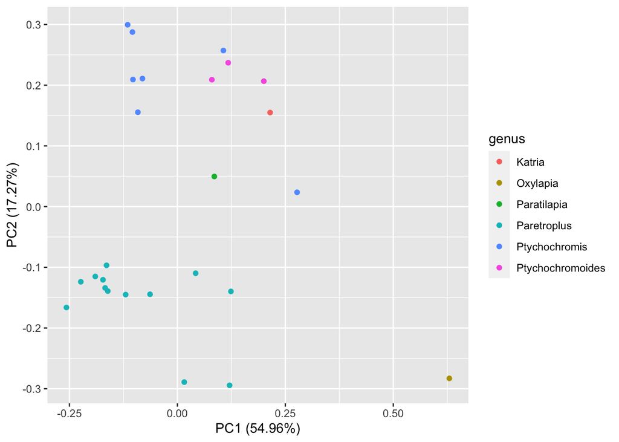

```r
bs_pc_plot <- autoplot(bs_pca, data  = bs_data_mod, colour = 'genus') #Plot the pca coloring the data by genus
bs_pc_plot
```

**Figure I Attempted to Replicate:**

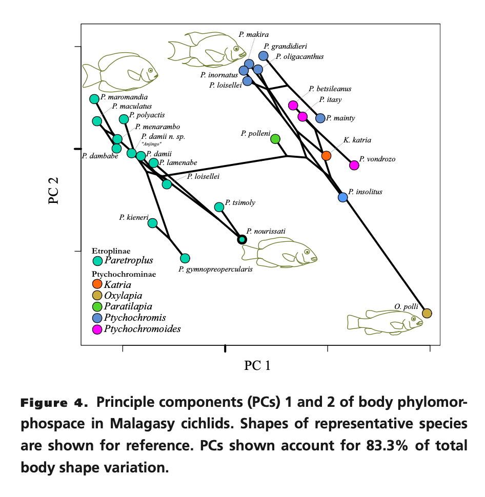

## Figure 5 Replication | PCA of Oral Jaw Phylomorphospace

**Data Preparation**

I used the same method see above to calculate the PCA of Oral Jaw Phylomorphospace. I prepped the data set in order to make the actual principle component analysis easier. Here I created a new variable oj_data which is the d2 dataset. Next, I modified the original d2 data set to separate the species column into genus name and species name. (This allowed me to later color the data points by genus.) I add the new column ‘genus’ to the oj_data data set, then I moved the genus name after the species name in the data set.

```r
#Prep the data
oj_data <- d2

d2_mod <- str_split_fixed(d2$species, "_", 2) #split the original species column into two (Genus name & Species name)
d2_mod <- as.data.frame(d2_mod, row.names = NULL, optional = FALSE) #Make the modified data set a data frame
oj_data_mod <- d2 %>% mutate(genus = d2_mod$V1) #Add the column genus
oj_data_mod <- oj_data_mod %>% relocate(genus, .after = species) #Move the new genus column after the species column
```

**PCA Analysis**

Again, here I used the same method seen in the Figure 4 analysis description. After prepping the data, I calculated the principle components. I started by scaling the data removing the first column of data, leaving only numeric values. Then I got the eigen values from the data set. Next I scaled the eigen values and calculated their variance. Lastly, I used the prcomp function to calculate the pca.

```r
#Calculate the Principal Components
oj_data_scaled <- scale(oj_data[, -1], #Use the oj_data removing the first column, leaving only numeric values in the data set.
                     center = TRUE,
                     scale = TRUE)
head(oj_data_scaled,3) #Print the first 3 lines of data for visualization
```

```
##             x1        y1         x2         y2         x3        y3          x4
## [1,] 0.5769516 0.2339572  0.2851613 -0.7955284 -0.4900708 0.8366445  0.05889993
## [2,] 1.3749616 0.9730097 -0.4246039 -0.8770611 -1.1896148 0.9035003  0.84867712
## [3,] 1.0396170 0.1542220 -0.2259917 -1.4956334 -0.4508153 1.4150336 -0.08206404
##              y4
## [1,] -0.7881095
## [2,] -1.3474070
## [3,] -1.1009799
```

```r
e2 <- eigen(cov(oj_data[, -1])) #Use the oj_data removing the first column, leaving only numeric values in the data set.
head(e2,3) #Print the first 3 lines of data for visualization
```

```
## $values
## [1] 4.973486e-03 1.741597e-03 4.177270e-04 2.351990e-06 3.411508e-19
## [6] 2.152061e-19 1.376311e-19 7.995997e-21
##
## $vectors
##             [,1]        [,2]         [,3]         [,4]        [,5]        [,6]
## [1,] -0.37266223  0.09577623 -0.394814775  0.177656591  0.00000000  0.00000000
## [2,] -0.26795777 -0.19746299 -0.008244185 -0.473951239  0.69791133  0.38768109
## [3,]  0.08057714  0.23361115  0.801292270 -0.149715072 -0.12660679  0.13736946
## [4,]  0.08520198 -0.23709115  0.207555255  0.786765548  0.45156222 -0.02100493
## [5,]  0.67167904  0.11105571 -0.367874574 -0.004518875 -0.08084855  0.49818917
## [6,] -0.19465123  0.73703989 -0.132975960  0.006224752  0.17265309 -0.27275366
## [7,] -0.37959394 -0.44044308 -0.038602928 -0.023422636 -0.47518591  0.06679305
## [8,]  0.37740701 -0.30248574 -0.066335107 -0.319039088  0.17559848 -0.70946704
##            [,7]          [,8]
## [1,]  0.0000000  8.151743e-01
## [2,] -0.1647192  1.920015e-07
## [3,] -0.2335725  4.301087e-01
## [4,] -0.2647309 -4.132792e-03
## [5,] -0.3643962  1.168258e-01
## [6,] -0.4885812 -2.413432e-01
## [7,] -0.6413186 -1.353774e-01
## [8,] -0.2558190  2.454758e-01
```

```r
e2.scaled <- eigen(cov(oj_data_scaled))
head(e2.scaled,3) #Print the first 3 lines of data for visualization
```

```
## $values
## [1]  4.770838e+00  2.385893e+00  8.343848e-01  8.884843e-03  1.622589e-16
## [6]  1.619532e-16  4.384739e-17 -1.361715e-16
##
## $vectors
##            [,1]        [,2]        [,3]        [,4]        [,5]       [,6]
## [1,] -0.4512459  0.03328379  0.17375889  0.28334378  0.00000000  0.0000000
## [2,] -0.3986318 -0.30464647 -0.15095783 -0.40136788  0.58336454 -0.3608604
## [3,]  0.1614443  0.35953334 -0.82426370 -0.19880813 -0.08365696 -0.1290359
## [4,]  0.2729426 -0.47884155 -0.33398041  0.70807780  0.14087134 -0.1410088
## [5,]  0.4303815  0.10753917  0.32606314 -0.02258024  0.12579281 -0.7477354
## [6,] -0.2246780  0.56246812  0.06550383  0.29271571 -0.17055503 -0.3484613
## [7,] -0.3513382 -0.40814301 -0.12759249 -0.08711572 -0.70088433 -0.3869445
## [8,]  0.4216170 -0.23024658  0.17081644 -0.35205081 -0.31095160  0.0546480
##             [,7]         [,8]
## [1,]  0.00000000  0.827522483
## [2,]  0.30425112 -0.035993988
## [3,] -0.05511982  0.314720917
## [4,]  0.20868630 -0.004224048
## [5,] -0.30442500  0.169627050
## [6,]  0.57054276 -0.259119409
## [7,] -0.17633256 -0.118548273
## [8,]  0.64152654  0.323842520
```

```r
e2.scaled$values #Calculate the variances
```

```
## [1]  4.770838e+00  2.385893e+00  8.343848e-01  8.884843e-03  1.622589e-16
## [6]  1.619532e-16  4.384739e-17 -1.361715e-16
```

```r
e2.scaled$values/6 #Proportion of variances
```

```
## [1]  7.951396e-01  3.976488e-01  1.390641e-01  1.480807e-03  2.704315e-17
## [6]  2.699220e-17  7.307899e-18 -2.269526e-17
```

```r
cumsum(e2.scaled$values/6) #Cumulative proportion
```

```
## [1] 0.7951396 1.1927884 1.3318525 1.3333333 1.3333333 1.3333333 1.3333333
## [8] 1.3333333
```

```r
oj_data_pc <- as.matrix(oj_data_scaled) %*% e2.scaled$vectors
head(oj_data_pc,3) #Print the first 3 lines of data for visualization
```

```
##           [,1]      [,2]        [,3]        [,4]          [,5]          [,6]
## [1,] -1.276573 1.0066899 -0.15155222 -0.02212728  3.820739e-09  4.972637e-09
## [2,] -2.897503 0.3607681  0.06778429  0.15419228 -3.387865e-09  1.950147e-08
## [3,] -1.922617 1.6569608  0.61125185  0.03770546 -2.255677e-09 -1.290221e-08
##               [,7]          [,8]
## [1,] -3.974458e-09  1.315179e-09
## [2,]  6.882773e-09 -2.662528e-09
## [3,]  8.330578e-09 -6.180536e-10
```

```r
oj_pca <- prcomp(oj_data[, -1], #Use the oj_data removing the first column, leaving only numeric values in the data set.
             center = TRUE,
             scale. = TRUE)
head(oj_pca$x,3) #Print the first 3 lines of data for visualization
```

```
##            PC1       PC2         PC3         PC4           PC5           PC6
## [1,] -1.276573 1.0066899 -0.15155222 -0.02212728 -4.007840e-09  6.037274e-09
## [2,] -2.897503 0.3607681  0.06778429  0.15419228 -1.263182e-08 -1.409780e-09
## [3,] -1.922617 1.6569608  0.61125185  0.03770546  1.244157e-08 -7.551049e-09
##                PC7           PC8
## [1,]  1.284608e-09 -1.639964e-09
## [2,]  1.588176e-08  5.697873e-09
## [3,] -3.811732e-09  3.872374e-09
```

```r
summary(oj_pca) #Summarize the data within the new pca
```

```
## Importance of components:
##                           PC1    PC2    PC3     PC4       PC5      PC6
## Standard deviation     2.1842 1.5446 0.9134 0.09426 1.003e-08 9.91e-09
## Proportion of Variance 0.5964 0.2982 0.1043 0.00111 0.000e+00 0.00e+00
## Cumulative Proportion  0.5964 0.8946 0.9989 1.00000 1.000e+00 1.00e+00
##                              PC7       PC8
## Standard deviation     7.509e-09 6.473e-09
## Proportion of Variance 0.000e+00 0.000e+00
## Cumulative Proportion  1.000e+00 1.000e+00
```

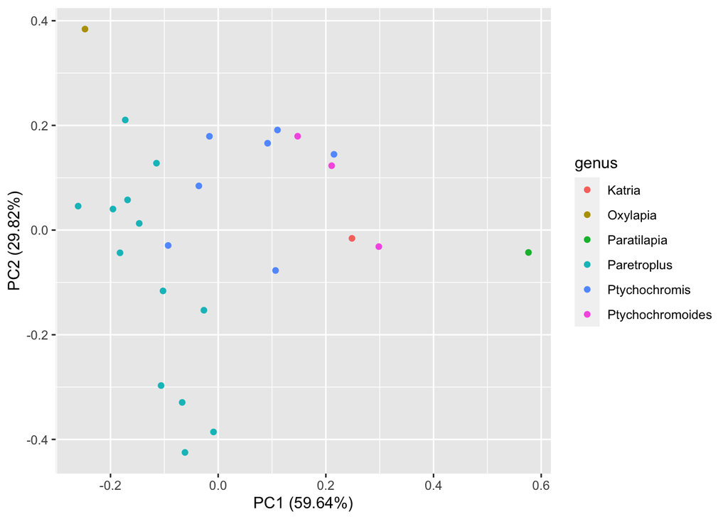

```r
oj_pc_plot <- autoplot(oj_pca, data  = oj_data_mod, colour = 'genus') #Plot the pca coloring the data by species
oj_pc_plot
```

**Figure I Attempted to Replicate:**

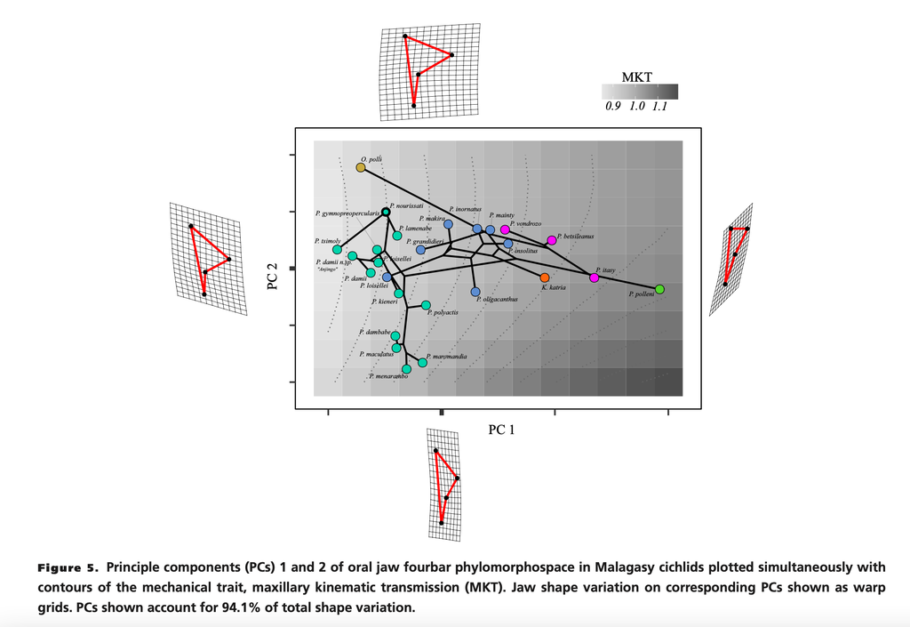

## Figure 6 Replication | Comparison MKT Density Plot

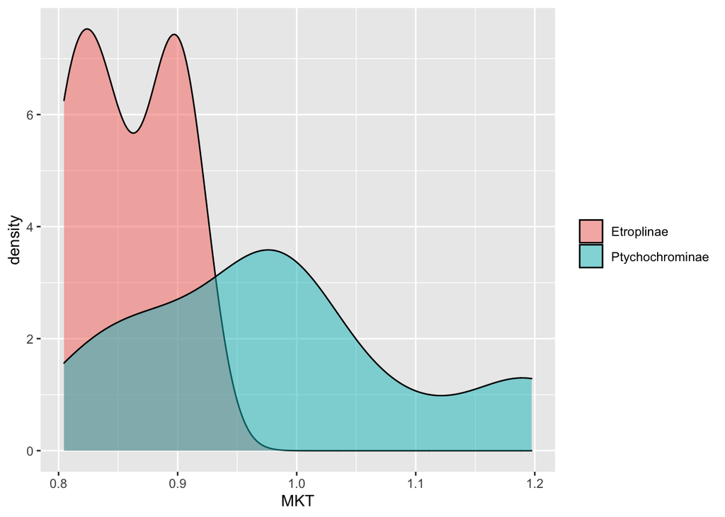

```r
#Actually works! I really did that OMG.

#Use ggplot to plot the comparison of MKT between subfamilies
mkt_plot <- ggplot(d3, aes(x = MKT)) +
       geom_density(aes(group = subfamily, fill = subfamily), alpha = 0.5) +
       xlim(c(min(d3$MKT), c(max(d3$MKT)))) +
       scale_fill_discrete(name = NULL , labels = c("Etroplinae", "Ptychochrominae"))

mkt_plot
```

**Figure I Attempted to Replicate:**

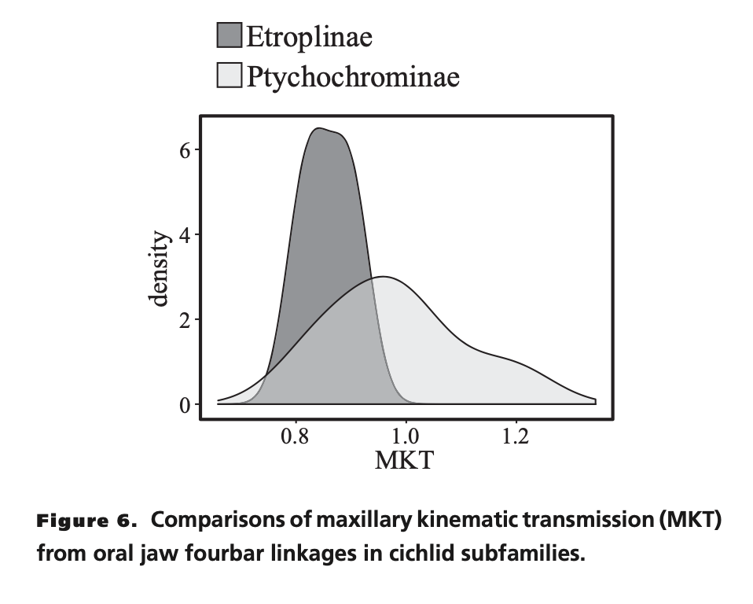

## Summary/Discussion

**Disclaimer** The Dryad information did provide “Usage Notes” for the data, however I decided to look at those after I completed the assignment to see if I used the correct data sets for each analysis I was attempting to replicate. To my knowledge I used the correct data sets for Figures 4 & 6, but not Figure 5.

**Figure 5 Replication** Like Figure 4, I was fairly successful with replicating the analysis. Again, the main problem I encountered during this section was that I had a hard time using the phyl.pca function in order to produce a phylogeny and pca simultaneously. I also may have used the wrong data set for this analysis since a few of the data points are a bit off. For this analysis I decided to just plot the PCA itself. Working with Figure 4 & 5 I learned how to separate characters within a single column into two individual columns, how to add/move columns in data frames, and one way to calculate principle component analyses.

**Figure 6 Replication** I believe I was quite successful with replicating this analysis. Honestly I am very happy with how this figure came out! It looks somewhat like the original figure although there are slight dips in the corresponding graphs. This was the main problem I encountered when programming this section of code. I couldn’t figure out how to fix the dip in the graph. I’m not sure if I input the data incorrectly or if I am using the wrong data set?

## References

Martinez,Christopher M., Sparks,John S. 2017. Malagasy cichlids differentially limit impacts of body shape evolution on oral jaw functional morphology. Evolution. Volume 71, Issue 9 p. 2219-2229. https://onlinelibrary.wiley.com/doi/10.1111/evo.13298

Dryad Data Download: https://datadryad.org/stash/dataset/doi:10.5061/dryad.k3b10